# Excel to R

# Module 2 Goals

- Data Types
- Vectors
- Matrixes
- Lists
- Tibbles and DataFrames
- Import and Export Data
- Data Provenance
- Viewing Data in R
- Display columns of DataFrames

# Understanding R from Excel

```r
c(1,2,3)
```

```
## [1] 1 2 3
```

Vector in Excel 3 rows in 1 column

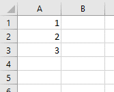

# Type in Excel vs. R

- Ignores text
- In R converts to first value

```r
c(1,2,3)
```

```
## [1] 1 2 3
```

```r
myNumbers <- c(1,2,3)
myNumbers * 2.2
```

```
## [1] 2.2 4.4 6.6
```

```r
sum(myNumbers)
```

```
## [1] 6
```

```r
typeof(myNumbers[3])
```

```
## [1] "double"
```

```r
myJunk <- c("1",2,3)
typeof(myNumbers[3])
```

```
## [1] "double"
```

```r
mean(myJunk)
```

```
## [1] NA
```

```r
mean(as.numeric(myJunk))
```

```
## [1] 2
```

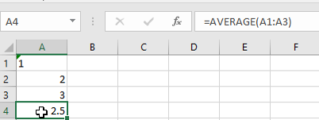

Install a package from tab

# Vectors in R

Allow quick transformations

```r
sum(myNumbers)
```

```
## [1] 6
```

```r
typeof(myNumbers)
```

```
## [1] "double"
```

```r
mean(myNumbers)
```

```
## [1] 2
```

```r
myDecimals <- c(1.0,2.3,3.4)
sum(myNumbers)
```

```
## [1] 6
```

```r
typeof(myDecimals)
```

```
## [1] "double"
```

```r
myDecimals <- as.numeric(myDecimals)
sum(myDecimals)
```

```
## [1] 6.7
```

```r
typeof(myDecimals)
```

```
## [1] "double"
```

```r
is(myDecimals)
```

```
## [1] "numeric" "vector"
```

```r
is(myNumbers)
```

```
## [1] "numeric" "vector"
```

# Can run operations on each item

Vector operations like multiply

```r
myNumbers * 2.2
```

```
## [1] 2.2 4.4 6.6
```

Different from aggregates like sum Summarize into single value (vector of 1)

```r
sum(myNumbers)
```

```
## [1] 6
```

# na =NULL

```r
badBoyz <- c("A",1,32)
is.numeric(badBoyz)
```

```
## [1] FALSE
```

```r
as.numeric(badBoyz)
```

```
## [1] NA  1 32
```

```r
sum(as.numeric(badBoyz), na.rm = TRUE)
```

```
## [1] 33
```

# Matrix

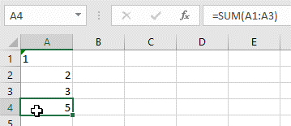

Install a package from tab

```r
myMatrix <- c(c(2,3,4),c(6,3,5))
myMatrix
```

```
## [1] 2 3 4 6 3 5
```

```r
myMatrix <- matrix(myMatrix, nrow = 3, ncol = 2)
myMatrix
```

```
##      [,1] [,2]
## [1,]    2    6
## [2,]    3    3
## [3,]    4    5
```

- Excel is Column-Row (B2)
- R is row-column[3,2] #Mo’ Matrix
- Can get rows or columns
- Result is vector

```r
sum(myMatrix)
```

```
## [1] 23
```

```r
myMatrix[,1]
```

```
## [1] 2 3 4
```

```r
myMatrix * 4
```

```
##      [,1] [,2]
## [1,]    8   24
## [2,]   12   12
## [3,]   16   20
```

```r
myMatrix[1,]
```

```
## [1] 2 6
```

# Tables in Excel =DataFrame in R

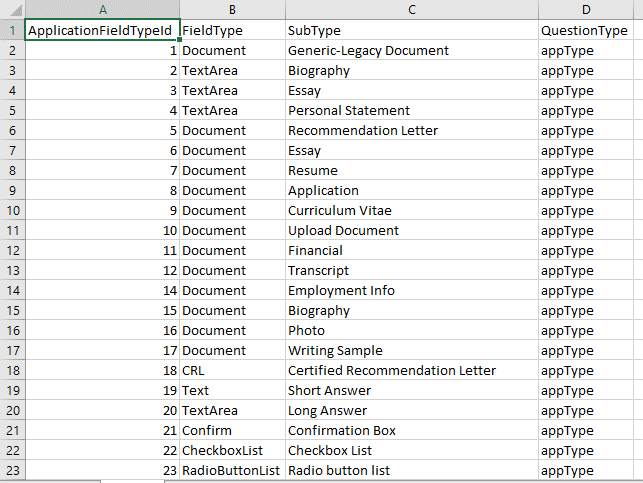

#DataFrame$ColumnName

```r
data.frame(myMatrix)
```

| X1 | X2 |
| --- | --- |
| 2 | 6 |
| 3 | 3 |
| 4 | 5 |

```r
colnames(myMatrix) <- c("First Column","Second Column")
myMatrix
```

```
##      First Column Second Column
## [1,]            2             6
## [2,]            3             3
## [3,]            4             5
```

```r
myMatrix <- data.frame(myMatrix)
typeof(myMatrix$First.Column)
```

```
## [1] "double"
```

# Import data from Excel

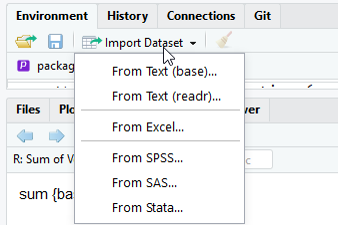

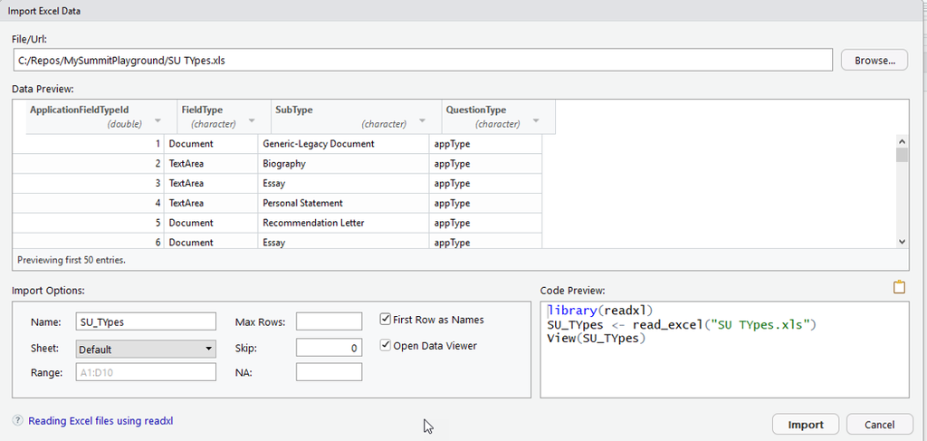

#We now have a tibbles (Note this only shows up in the Script view and not in the R Markdown view. I am not sure why)

```r
library(readxl)
SU_TYpes=read_excel("../../Data/SU TYpes.xls")
str(SU_TYpes)
```

```
## Classes 'tbl_df', 'tbl' and 'data.frame':    52 obs. of  4 variables:
##  $ ApplicationFieldTypeId: num  1 2 3 4 5 6 7 8 9 10 ...
##  $ FieldType             : chr  "Document" "TextArea" "TextArea" "TextArea" ...
##  $ SubType               : chr  "Generic-Legacy Document" "Biography" "Essay" "Personal Statement" ...
##  $ QuestionType          : chr  "appType" "appType" "appType" "appType" ...
```

```r
SU_TYpes[1,1]
```

| ApplicationFieldTypeId |
| --- |
| 1 |

```r
SU_TYpes[1,]
```

| ApplicationFieldTypeId | FieldType | SubType | QuestionType |
| --- | --- | --- | --- |
| 1 | Document | Generic-Legacy Document | appType |

```r
SU_TYpes[,1]
```

| ApplicationFieldTypeId |
| --- |
| 1 |
| 2 |
| 3 |
| 4 |
| 5 |
| 6 |
| 7 |
| 8 |
| 9 |
| 10 |

[output cut: 42 more lines]

(not a whole lot different but better for technical reasons of conversion) #Factors =categorical variables

```r
factor_set <- SU_TYpes
factor_set$ApplicationFieldTypeId <- as.factor(factor_set$ApplicationFieldTypeId)
str(factor_set$ApplicationFieldTypeId)
```

```
##  Factor w/ 43 levels "1","2","3","4",..: 1 2 3 4 5 6 7 8 9 10 ...
```

# Data Provenance

- Excel is destructive
- Make changes =changes data
- R can keep original data
- If make mistakes can rerun the script

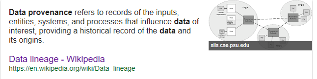

# Other Data Imports- Read(base)

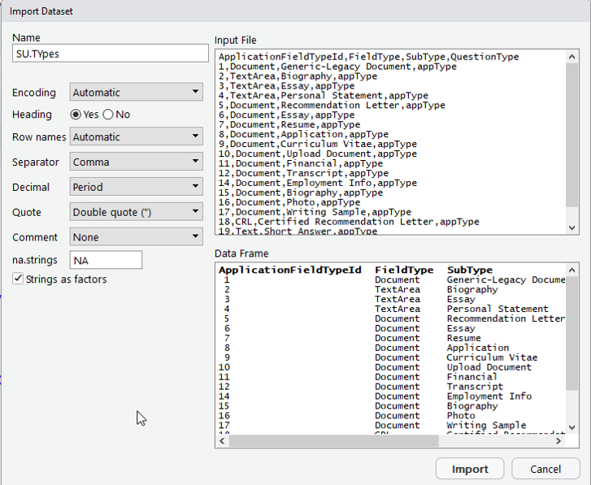

#Write and read data csv

```r
write.csv(SU_TYpes,"mycsv.csv")
SU_TYpes_from_disk <- read.csv("mycsv.csv")
str(SU_TYpes_from_disk)
```

```
## 'data.frame':    52 obs. of  5 variables:
##  $ X                     : int  1 2 3 4 5 6 7 8 9 10 ...
##  $ ApplicationFieldTypeId: int  1 2 3 4 5 6 7 8 9 10 ...
##  $ FieldType             : Factor w/ 23 levels "Attachment","CheckboxList",..: 8 21 21 21 8 8 8 8 8 8 ...
##  $ SubType               : Factor w/ 46 levels "All","Application",..: 23 5 19 33 36 19 37 2 11 44 ...
##  $ QuestionType          : Factor w/ 2 levels "appType","attType": 1 1 1 1 1 1 1 1 1 1 ...
```

# Ways to view data

```r
str(SU_TYpes)
```

```
## Classes 'tbl_df', 'tbl' and 'data.frame':    52 obs. of  4 variables:
##  $ ApplicationFieldTypeId: num  1 2 3 4 5 6 7 8 9 10 ...
##  $ FieldType             : chr  "Document" "TextArea" "TextArea" "TextArea" ...
##  $ SubType               : chr  "Generic-Legacy Document" "Biography" "Essay" "Personal Statement" ...
##  $ QuestionType          : chr  "appType" "appType" "appType" "appType" ...
```

```r
summary(SU_TYpes)
```

```
##  ApplicationFieldTypeId  FieldType           SubType
##  Min.   : 1.00          Length:52          Length:52
##  1st Qu.: 7.00          Class :character   Class :character
##  Median :18.50          Mode  :character   Mode  :character
##  Mean   :19.65
##  3rd Qu.:31.25
##  Max.   :44.00
##  QuestionType
##  Length:52
##  Class :character
##  Mode  :character
##
##
##
```

# Subseting and filtering

```r
subset(SU_TYpes,ApplicationFieldTypeId > 5)
```

| ApplicationFieldTypeId | FieldType | SubType | QuestionType |
| --- | --- | --- | --- |
| 6 | Document | Essay | appType |
| 7 | Document | Resume | appType |
| 8 | Document | Application | appType |
| 9 | Document | Curriculum Vitae | appType |
| 10 | Document | Upload Document | appType |
| 11 | Document | Financial | appType |
| 12 | Document | Transcript | appType |
| 14 | Document | Employment Info | appType |
| 15 | Document | Biography | appType |
| 16 | Document | Photo | appType |

[output cut: 32 more lines]

```r
library(dplyr)
filter(SU_TYpes, FieldType =="Document")
```

| ApplicationFieldTypeId | FieldType | SubType | QuestionType |
| --- | --- | --- | --- |
| 1 | Document | Generic-Legacy Document | appType |
| 5 | Document | Recommendation Letter | appType |
| 6 | Document | Essay | appType |
| 7 | Document | Resume | appType |
| 8 | Document | Application | appType |
| 9 | Document | Curriculum Vitae | appType |
| 10 | Document | Upload Document | appType |
| 11 | Document | Financial | appType |
| 12 | Document | Transcript | appType |
| 14 | Document | Employment Info | appType |

[output cut: 11 more lines]

# More ways to view data

```r
head(SU_TYpes)
```

| ApplicationFieldTypeId | FieldType | SubType | QuestionType |
| --- | --- | --- | --- |
| 1 | Document | Generic-Legacy Document | appType |
| 2 | TextArea | Biography | appType |
| 3 | TextArea | Essay | appType |
| 4 | TextArea | Personal Statement | appType |
| 5 | Document | Recommendation Letter | appType |
| 6 | Document | Essay | appType |

```r
tail(SU_TYpes)
```

| ApplicationFieldTypeId | FieldType | SubType | QuestionType |
| --- | --- | --- | --- |
| 4 | DropDown | DropDown | attType |
| 5 | List | List | attType |
| 6 | Yes/No | Yes/No | attType |
| 7 | Attachment | Attachment | attType |
| 8 | DateTime | DateTime | attType |
| 9 | FastFind | FastFind | attType |

# Filter in View mode

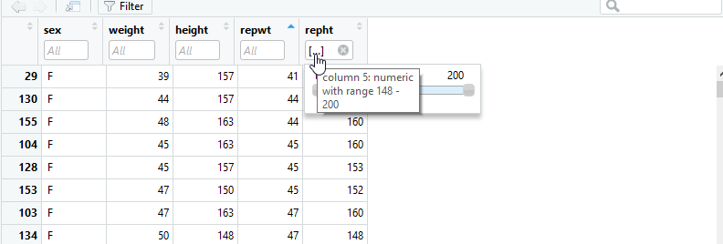

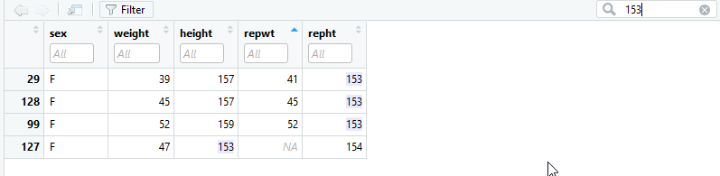

# Functions vs Sub

- Functions return a value
- In R have return statement in parens

```r
first_function <- function(x){return (x)}
first_function("x")
```

```
## [1] "x"
```

- Can be on multiple lines

```r
snoopdogit <-
  function(x){
    return (paste(x,"izzle",sep=""))
    }
snoopdogit("sing")
```

```
## [1] "singizzle"
```

# Make your own functions

```r
fixemplid <- function(x){

  if (nchar(x)=="6"){
    return (paste("00",x, sep=""))
  }


}
fixemplid(("123456"))
```

```
## [1] "00123456"
```

# Pro advice

- Do 1 thing
- Verify it works (Check it in)
- Do the next thing #Make it better

```r
fixemplid <- function(x){

  if (nchar(x)=="6"){
    return (paste("00",x, sep=""))
  }
  if (nchar(x)=="7"){
    return (paste("0",x, sep=""))
  }
  return (x)

}
fixemplid(("123456"))
```

```
## [1] "00123456"
```

```r
three_emplids <- c("123456","1234567","12345678")
lapply(three_emplids, fixemplid)
```

```
## [[1]]
## [1] "00123456"
##
## [[2]]
## [1] "01234567"
##
## [[3]]
## [1] "12345678"
```